# **♻️ Waste Classification**

Questo progetto ha come obiettivo la creazione e l'addestramento di modelli di **rete neurale convoluzionale (CNN)** per classificare immagini di rifiuti in una delle seguenti **5 categorie**:

- Plastica
- Carta
- Vetro
- Organico
- Indifferenziata

Il modello sarà in grado di riconoscere correttamente il tipo di rifiuto a partire da un'immagine, facilitando così una corretta raccolta differenziata.

Il dataset è disponibile al seguente link su Kaggle: [Garbage Classification - Kaggle](https://www.kaggle.com/datasets/mostafaabla/garbage-classification)

Il dataset originale contiene alcune classi in eccesso rispetto a quelle di interesse. In questa implementazione, **sono state mantenute solo le 5 classi elencate sopra**, scartando le rimanenti per focalizzarsi su un problema più mirato e realistico.

Questo progetto include:

- Preprocessing delle immagini ed espolarazione
- Data augmentation per migliorare la generalizzazione
- Modello CNN personalizzato
- Tuning degli iperparametri
- Transfer learning con MobileNet
- Valutazione del modello con metodi visivi e quantitativi
- Predizioni su immagini reali

```python
import tensorflow as tf
from tensorflow.keras.utils import image_dataset_from_directory
from tensorflow.data import AUTOTUNE
from tensorflow.keras import layers, models, callbacks, regularizers, applications, utils
from sklearn.metrics import confusion_matrix

import matplotlib.pyplot as plt
import seaborn as sn
import pandas as pd
import numpy as np
```

```python
from google.colab import drive
drive.mount('/content/drive')
```

```python
import os

path = '/content/drive/MyDrive/Smart_Waste_Project/data/raw'
```

# **🧹 Data Preparation**

```python
img_height = 224
img_width = 224
batch_size = 64
```

Il dataset contiene un totale di *4989 immagini*, suddivise nel seguente modo:

- *3992 immagini* per il **training set** (80%)
- *997 immagini* per il **test set** (20%)

```python
# Caricamento training set dal path
train = image_dataset_from_directory(path,
                                      validation_split = 0.2,
                                      subset = "training",
                                      seed = 42,
                                      image_size = (img_height, img_width),
                                      batch_size = batch_size,

                                     label_mode = "categorical")
# Caricamento test set dal path
test = image_dataset_from_directory(path,
                                    validation_split = 0.2,
                                    subset = "validation",
                                    seed = 42,
                                    image_size = (img_height, img_width),
                                    batch_size = batch_size,
                                    label_mode = "categorical")
```

```
Found 4989 files belonging to 5 classes.
Using 3992 files for training.
Found 4989 files belonging to 5 classes.
Using 997 files for validation.
```

```python
class_names = train.class_names

print(f'{class_names = }')
```

```
class_names = ['glass', 'organic', 'paper', 'plastic', 'trash']
```

```python
# Il dataset viene normalizzato:  i valori dei pixel, originariamente compresi tra [0, 255], vengono scalati nell’intervallo [0, 1]
normalization = layers.Rescaling(1./255)

# Applico normalizzazione al train e test set
train = train.map(lambda x,y: (normalization(x),y) )
test = test.map(lambda x,y: (normalization(x),y) )
```

```python
# Ottimizzo il caricamento dei dati durante l'addestramento
train = train.cache().prefetch(buffer_size = AUTOTUNE)
test = test.cache().prefetch(buffer_size = AUTOTUNE)
```

- *cache()*: memorizza temporaneamente il dataset in memoria (o su disco), evitando di ricaricarlo da zero ad ogni epoca, riducendo così il tempo di caricamento e migliorando l'efficienza.
- *prefetch(buffer_size=AUTOTUNE)*: permette di caricare in anticipo un certo numero di batch di dati mentre la GPU/TPU sta ancora processando quelli correnti, minimizzando i tempi di attesa e massimizzando l'uso delle risorse.

```python
# Controllo conformità delle dimensioni
for image, labels in train:
  print(image.shape)
  print(labels.shape) #labels è in formato one-hot encoding
  break
```

```
(64, 224, 224, 3)
(64, 5)
```

```python
from collections import Counter

# Funzione che conta la frequenza assoluta delle 5 classi nel dataset in input
def count_class(dataset):

  total = 0
  counter = Counter()
  i = 1

  for _, labels in dataset:
    class_id = tf.argmax(labels, axis = 1).numpy()  # Converte le etichette da one-hot encoding a interi (indice della classe)
    counter.update(class_id)
    total += len(class_id)
    print("Caricato batch", i)
    i += 1

  return total, counter
```

```python
total_images_train, counter_train = count_class(train)
total_images_test, counter_test = count_class(test)
```

```
Caricato batch 1
Caricato batch 2
Caricato batch 3
Caricato batch 4
Caricato batch 5
Caricato batch 6
Caricato batch 7
Caricato batch 8
Caricato batch 9
Caricato batch 10
Caricato batch 11
Caricato batch 12
Caricato batch 13
Caricato batch 14
Caricato batch 15
Caricato batch 16
Caricato batch 17
Caricato batch 18
Caricato batch 19
Caricato batch 20
Caricato batch 21
Caricato batch 22
Caricato batch 23
Caricato batch 24
Caricato batch 25
Caricato batch 26
Caricato batch 27
Caricato batch 28
Caricato batch 29
Caricato batch 30
Caricato batch 31
Caricato batch 32
Caricato batch 33
Caricato batch 34
Caricato batch 35
Caricato batch 36
Caricato batch 37
Caricato batch 38
Caricato batch 39
Caricato batch 40
```

[output cut: 24 more lines]

```
Caricato batch 2
Caricato batch 3
Caricato batch 4
Caricato batch 5
Caricato batch 6
Caricato batch 7
Caricato batch 8
Caricato batch 9
Caricato batch 10
Caricato batch 11
Caricato batch 12
Caricato batch 13
Caricato batch 14
Caricato batch 15
Caricato batch 16
```

```python
print('----- SUMMARY -----\n')
print('Immagini totali nel training -->', total_images_train)
print('Immagini totali nel test -->', total_images_test)
print('Immagini totali nel dataset -->', total_images_test + total_images_train)
print()
print('DISTRIBUZIONE IMMAGINI NEL TRAINING')
for i, name in enumerate(class_names):
    print(f'{name} --> {counter_train[i]}')
print()
print('DISTRIBUZIONE IMMAGINI NEL TEST')
for i, name in enumerate(class_names):
    print(f'{name} --> {counter_test[i]}')
```

```
----- SUMMARY -----

Immagini totali nel training --> 3992
Immagini totali nel test --> 997
Immagini totali nel dataset --> 4989

DISTRIBUZIONE IMMAGINI NEL TRAINING
glass --> 1121
organic --> 803
paper --> 815
plastic --> 703
trash --> 550

DISTRIBUZIONE IMMAGINI NEL TEST
glass --> 261
organic --> 192
paper --> 235
plastic --> 162
trash --> 147
```

# **🧾 Data visualization**

```python
# Funzione che grafica le prime tre immagini e le loro etichette corrisponenti dal dataset in input
def show_images(data, class_names, title):
    plt.figure( figsize = (7,4) )

    for img, labels in data.take(1): # data.take(1) --> lavora sul primo batch di data

        for i in range(3):

            axis = plt.subplot(1,3, i+1)
            image = img[i].numpy() # estrae l'imagine i-esima e la converte in oggetto numpy
            label = tf.argmax(labels[i]).numpy() # estrae l'etichetta corrispondente all'immagine
            plt.imshow(image)
            plt.title(class_names[label], fontsize = 15)
            plt.axis('off')

        plt.suptitle(title, fontsize = 24, color = "#2343f8")
        plt.show()
```

[figure not shown]

```python
show_images(train, class_names, title = 'TRAINING')
```

[figure not shown]

```python
show_images(test, class_names, title = 'TEST')
```

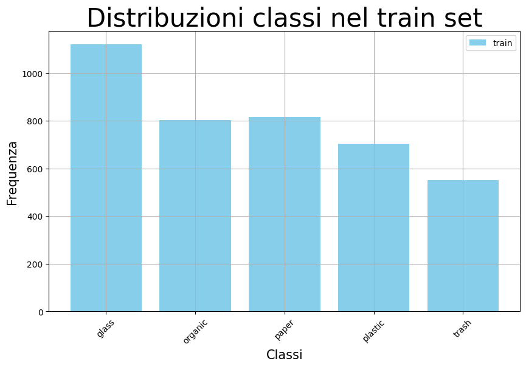

```python
# Visualizzazione distribuzione delle classi
x = np.arange(len(class_names))
train_values = [counter_train.get(i, 0) for i in range(len(class_names))]

plt.figure( figsize = (10,6) )
plt.bar(x, train_values, label = 'train', color = 'skyblue')
plt.grid(True)
plt.legend()
plt.xlabel('Classi', fontsize = 15)
plt.ylabel('Frequenza', fontsize = 15)
plt.title('Distribuzioni classi nel train set', fontsize = 30)
plt.xticks(x, class_names, rotation=45)
plt.show()
```

$$weight_i = \frac{\max_{j}f_j}{f_i}$$

essendo $f_i$ la frequenza assoluta dell'i-esima classe nel training set.  
In questo modo, per costruzione, il peso corrispondente alla classe **vetro** sarà pari a 1 (essendo vetro la classe più frequente)

```python
def compute_weights(counter, class_names):
  max_freq = counter.most_common(1)[0][1]

  weights = dict()

  for i, name in enumerate(class_names):
    freq = counter[i]
    weights[i] = max_freq/freq

  return weights
```

La **data augmentation** si basa sul seguente concetto: *la rappresentazione semantica di un immagine **non cambia** se si effettuano trasformazioni sulla stessa*.  
In sostanza un'immagine che rappresentanta un cane continuerà a rappresentarlo anche se viene:

- ruotata
- sfocata
- traslata
- capovolta
- modificata in luminosità o colore

La data augmentation consente di creare un dataset più ampio e variegato a partire da dati reali, migliorando le capacità di generalizzazione del modello.

```python
def data_augmentation():

  return models.Sequential([
    layers.RandomRotation(0.2),
    layers.RandomZoom(0.2),
    layers.RandomTranslation(0.1, 0.1),
    layers.RandomFlip("horizontal")
  ])
```

# **🔧 Modelling**

Qui di seguito la definizione di un modello di **CNN personalizzata** dipendente da diversi parametri

## Parametri

- `p` : *(int)* Numero di blocchi `Conv2D + MaxPooling`. Deve essere uguale alla lunghezza della lista `filters`.
  - Default: `p = 2`
- `filters`: *(list of int)* Lista che specifica il **numero di filtri** per ciascun blocco convoluzionale.
  - Default: `filters = [32,64]`
- `k`: *(tuple of int)* Dimensione del **kernel** per le convoluzioni.
  - Default: `k = (3,3)`
- `pool_size`: *(tuple of int)* Dimensione della finestra di **pooling** per ogni layer `MaxPooling`.
  - Default: `pool_size = (2,2)`
- `activation`: *(str)* Funzione di **attivazione** da usare in tutti i layer densi e convoluzionali.
  - Default: `activation = 'relu'`
- `n`: *(int)* Numero di neuroni del primo layer `Dense` dopo il `Flatten`.
  - Default: `n = 128`
- `drop`: *(list of bool)* Lista di tre valori booleani che indicano se applicare i **dropout layer**:
  - `drop[0]`: prima del primo layer `Dense`
  - `drop[1]`: dopo il primo `Dense`
  - `drop[2]`: dopo il secondo `Dense`
  - Default: `drop = [False, False, False]`
- `reg`: *(Keras regularizer or None)* **Regularizzatore** da applicare ai layer `Dense` o `None` se non si desidera.
  - Default: `reg = None`
- `aug`: *(bool)* Se `True`, applica **data augmentation**.
  - Default: `aug = False`

## Output

Restituisce un oggetto `tf.keras.Sequential` che rappresenta la rete neurale definita.

```python
def my_cnn(p = 2, filters = [32,64], k = (3,3), pool_size = (2,2), activation = 'relu', n = 128,
           drop = [False, False, False], reg = None, aug = False):

    model = models.Sequential( [layers.Input(shape = (224,224,3))] )

    if aug:
      model.add(data_augmentation())

    if not p == len(filters):
        raise ValueError('the length of np must be equal to p!')


    for i in range(p):

        model.add(
            layers.Conv2D(filters = filters[i], kernel_size = k, activation = activation, padding = 'same')
            )
        model.add(
            layers.MaxPool2D(pool_size = pool_size)
            )

    model.add( layers.Flatten() )

    if drop[0]:
      model.add( layers.Dropout(0.2) )

    model.add( layers.Dense(units = n, activation = activation, kernel_regularizer = reg) )
    if drop[1]:
      model.add( layers.Dropout(0.2) )
    model.add( layers.Dense(units = int(n/2), activation = activation, kernel_regularizer = reg) )
    if drop[2]:
      model.add( layers.Dropout(0.2) )

    model.add( layers.Dense(units = 5, activation = 'softmax') )

    return model
```

## **1° Modello: Architettura Semplice**

> Modello pensato come **punto di partenza** semplice per valutare la struttura e le performance iniziali della rete.

### Impostazioni del modello

| Parametro | Valore |
| --- | --- |
| `p` | 3 |
| `filters` | `[32, 32, 64]` |
| `n` | 128 |
| `optimizer` | `'adam'` |
| `loss` | `'categorical_crossentropy'` |
| `metrics` | `['accuracy']` |
| `epochs` | 20 |

### Risultati finali

| Metrica | Valore |
| --- | --- |
| Tempo di training | 1 min 30 sec |
| Accuracy (training) | 99% |
| **Accuracy (testing)** | **69%** |
| Loss (training) | 0.035 |
| **Loss (testing)** | **1.829** |
| **Best validation accuracy** | **72%** |

```python
model = my_cnn(p = 3, filters = [32, 32, 64], n = 128 )
```

```python
model.summary() # Visualizzo struttura del modello
```

```
Model: "sequential"
```

```
┏━━━━━━━━━━━━━━━━━━━━━━━━━━━━━━━━━┳━━━━━━━━━━━━━━━━━━━━━━━━┳━━━━━━━━━━━━━━━┓
┃ Layer (type)                    ┃ Output Shape           ┃       Param # ┃
┡━━━━━━━━━━━━━━━━━━━━━━━━━━━━━━━━━╇━━━━━━━━━━━━━━━━━━━━━━━━╇━━━━━━━━━━━━━━━┩
│ conv2d (Conv2D)                 │ (None, 224, 224, 32)   │           896 │
├─────────────────────────────────┼────────────────────────┼───────────────┤
│ max_pooling2d (MaxPooling2D)    │ (None, 112, 112, 32)   │             0 │
├─────────────────────────────────┼────────────────────────┼───────────────┤
│ conv2d_1 (Conv2D)               │ (None, 112, 112, 32)   │         9,248 │
├─────────────────────────────────┼────────────────────────┼───────────────┤
│ max_pooling2d_1 (MaxPooling2D)  │ (None, 56, 56, 32)     │             0 │
├─────────────────────────────────┼────────────────────────┼───────────────┤
│ conv2d_2 (Conv2D)               │ (None, 56, 56, 64)     │        18,496 │
├─────────────────────────────────┼────────────────────────┼───────────────┤
│ max_pooling2d_2 (MaxPooling2D)  │ (None, 28, 28, 64)     │             0 │
├─────────────────────────────────┼────────────────────────┼───────────────┤
│ flatten (Flatten)               │ (None, 50176)          │             0 │
├─────────────────────────────────┼────────────────────────┼───────────────┤
│ dense (Dense)                   │ (None, 128)            │     6,422,656 │
├─────────────────────────────────┼────────────────────────┼───────────────┤
│ dense_1 (Dense)                 │ (None, 64)             │         8,256 │
├─────────────────────────────────┼────────────────────────┼───────────────┤
│ dense_2 (Dense)                 │ (None, 5)              │           325 │
└─────────────────────────────────┴────────────────────────┴───────────────┘
```

```
 Total params: 6,459,877 (24.64 MB)
```

```
 Trainable params: 6,459,877 (24.64 MB)
```

```
 Non-trainable params: 0 (0.00 B)
```

```python
model.compile(optimizer = 'adam', loss = 'categorical_crossentropy', metrics = ['accuracy'])
```

```python
val = train.take(6)     # Considero i primi 6 batch dei training da usare come validation per misurare l'accuracy e l'andamento del modello
train = train.skip(6)   # I restanti 57 batch saranno utilizzati per allenare la rete
```

```python
import time

start = time.time()
history = model.fit(train, epochs = 20, verbose = 1, validation_data = val)
end = time.time()
```

```
57/57 ━━━━━━━━━━━━━━━━━━━━ 17s 138ms/step - accuracy: 0.3345 - loss: 1.6281 - val_accuracy: 0.5495 - val_loss: 1.1445
57/57 ━━━━━━━━━━━━━━━━━━━━ 3s 61ms/step - accuracy: 0.5515 - loss: 1.0531 - val_accuracy: 0.6641 - val_loss: 0.8913
57/57 ━━━━━━━━━━━━━━━━━━━━ 5s 62ms/step - accuracy: 0.6482 - loss: 0.8730 - val_accuracy: 0.6979 - val_loss: 0.8448
57/57 ━━━━━━━━━━━━━━━━━━━━ 5s 61ms/step - accuracy: 0.7245 - loss: 0.7118 - val_accuracy: 0.7031 - val_loss: 0.8098
57/57 ━━━━━━━━━━━━━━━━━━━━ 3s 61ms/step - accuracy: 0.7851 - loss: 0.5593 - val_accuracy: 0.6641 - val_loss: 1.0200
57/57 ━━━━━━━━━━━━━━━━━━━━ 4s 63ms/step - accuracy: 0.8267 - loss: 0.4878 - val_accuracy: 0.6224 - val_loss: 1.1111
57/57 ━━━━━━━━━━━━━━━━━━━━ 5s 62ms/step - accuracy: 0.8405 - loss: 0.4287 - val_accuracy: 0.7240 - val_loss: 0.9877
57/57 ━━━━━━━━━━━━━━━━━━━━ 4s 62ms/step - accuracy: 0.8746 - loss: 0.3559 - val_accuracy: 0.6667 - val_loss: 1.1478
57/57 ━━━━━━━━━━━━━━━━━━━━ 4s 63ms/step - accuracy: 0.8894 - loss: 0.3067 - val_accuracy: 0.6536 - val_loss: 1.3257
57/57 ━━━━━━━━━━━━━━━━━━━━ 4s 62ms/step - accuracy: 0.8970 - loss: 0.3041 - val_accuracy: 0.7057 - val_loss: 1.1091
57/57 ━━━━━━━━━━━━━━━━━━━━ 4s 62ms/step - accuracy: 0.9234 - loss: 0.2180 - val_accuracy: 0.6823 - val_loss: 1.1937
57/57 ━━━━━━━━━━━━━━━━━━━━ 4s 62ms/step - accuracy: 0.9263 - loss: 0.1988 - val_accuracy: 0.7135 - val_loss: 1.3077
57/57 ━━━━━━━━━━━━━━━━━━━━ 4s 63ms/step - accuracy: 0.9467 - loss: 0.1552 - val_accuracy: 0.6979 - val_loss: 1.4002
57/57 ━━━━━━━━━━━━━━━━━━━━ 5s 62ms/step - accuracy: 0.9674 - loss: 0.1007 - val_accuracy: 0.7240 - val_loss: 1.1971
57/57 ━━━━━━━━━━━━━━━━━━━━ 4s 62ms/step - accuracy: 0.9722 - loss: 0.0901 - val_accuracy: 0.7083 - val_loss: 1.5855
57/57 ━━━━━━━━━━━━━━━━━━━━ 4s 63ms/step - accuracy: 0.9760 - loss: 0.0742 - val_accuracy: 0.7057 - val_loss: 1.5890
57/57 ━━━━━━━━━━━━━━━━━━━━ 4s 62ms/step - accuracy: 0.9820 - loss: 0.0593 - val_accuracy: 0.6875 - val_loss: 1.6973
57/57 ━━━━━━━━━━━━━━━━━━━━ 4s 62ms/step - accuracy: 0.9744 - loss: 0.0790 - val_accuracy: 0.7240 - val_loss: 1.3080
57/57 ━━━━━━━━━━━━━━━━━━━━ 4s 62ms/step - accuracy: 0.9775 - loss: 0.0836 - val_accuracy: 0.7188 - val_loss: 1.6334
57/57 ━━━━━━━━━━━━━━━━━━━━ 4s 63ms/step - accuracy: 0.9852 - loss: 0.0494 - val_accuracy: 0.7057 - val_loss: 1.5196
```

```python
print("Tempo impiegato per l'addestramento -->", round(end-start,3),'sec')
```

```
Tempo impiegato per l'addestramento --> 90.169 sec
```

```python
pd.DataFrame(history.history)  # Visualizzo in formato più comodo l'accuracy e la loss sia sul training che sul validation, in funzione delle epoche
```

|  | accuracy | loss | val_accuracy | val_loss |
| --- | --- | --- | --- | --- |
| 0 | 0.418792 | 1.362218 | 0.549479 | 1.144476 |
| 1 | 0.600333 | 0.967464 | 0.664062 | 0.891261 |
| 2 | 0.682927 | 0.802337 | 0.697917 | 0.844835 |
| 3 | 0.740022 | 0.672571 | 0.703125 | 0.809778 |
| 4 | 0.802106 | 0.527363 | 0.664062 | 1.020015 |
| 5 | 0.839523 | 0.451248 | 0.622396 | 1.111056 |
| 6 | 0.864745 | 0.371987 | 0.723958 | 0.987726 |
| 7 | 0.883315 | 0.328612 | 0.666667 | 1.147774 |
| 8 | 0.879157 | 0.335758 | 0.653646 | 1.325734 |
| 9 | 0.896341 | 0.296137 | 0.705729 | 1.109141 |
| 10 | 0.922118 | 0.222389 | 0.682292 | 1.193721 |
| 11 | 0.929047 | 0.197725 | 0.713542 | 1.307721 |
| 12 | 0.951219 | 0.145024 | 0.697917 | 1.400169 |
| 13 | 0.963692 | 0.110766 | 0.723958 | 1.197083 |
| 14 | 0.969789 | 0.097755 | 0.708333 | 1.585502 |
| 15 | 0.975055 | 0.076193 | 0.705729 | 1.589049 |
| 16 | 0.976164 | 0.072509 | 0.687500 | 1.697336 |
| 17 | 0.960920 | 0.123388 | 0.723958 | 1.308038 |
| 18 | 0.975610 | 0.085965 | 0.718750 | 1.633354 |
| 19 | 0.985310 | 0.047935 | 0.705729 | 1.519597 |

```python
# Funzione che grafica l'andamento della metrica specificata durante le epoche sia per il training set che per il validation set
def plot_graphs(history, string, title = None):

  plt.plot(history.history[string], label = 'test')
  plt.plot(history.history['val_'+string], label = 'validation')

  plt.xlabel("epoche")
  plt.legend()
  plt.title(title, fontsize = 20)
  plt.grid(True)
```

## Interpretazione dei Risultati

Dai grafici sottostanti si osserva che, a partire dall’**ottava epoca**, l’accuracy sul validation set sembra **stabilizzarsi** (intorno al 70%). L’accuracy sul training set tende invece ad **aumentare**.

Inoltre, si nota una **decrescita della loss sul training set**, accompagnata da un **aumento della loss sul validation**.

> Questo è un chiaro segnale di **overfitting**, ossia il modello si sta adattando troppo bene ai dati di training e perde capacità di generalizzazione sui dati di validation.

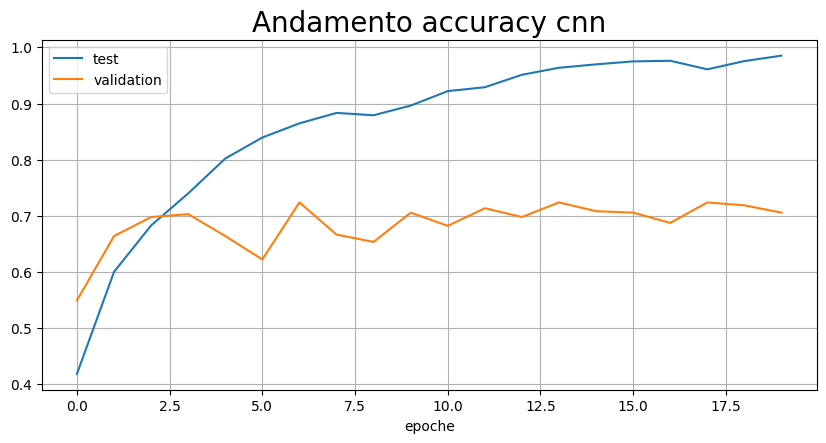

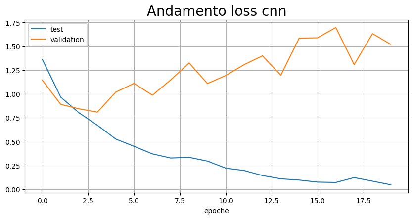

```python
plt.figure( figsize = (10,10) )

plt.subplot(2,1,1)
plot_graphs(history, 'accuracy', title = 'Andamento accuracy cnn')
plt.show()

plt.figure( figsize = (10,10) )

plt.subplot(2,1,2)
plot_graphs(history, 'loss', title = 'Andamento loss cnn')
plt.show()
```

```python
print('--- PERFORMANCE CNN ---\n')

loss_train, accuracy_train = model.evaluate(train, verbose = 0)
print(f"Training Accuracy: {accuracy_train :.4f}")
print(f"Training Loss: {loss_train :.4f}")
print()
loss_test, accuracy_test = model.evaluate(test, verbose = 0)
print(f"Testing Accuracy:  {accuracy_test:.4f}")
print(f"Testing Loss:  {loss_test:.4f}")
```

```
--- PERFORMANCE CNN ---

Training Accuracy: 0.9911
Training Loss: 0.0351

Testing Accuracy:  0.6911
Testing Loss:  1.8289
```

## **2° Modello: Utilizzo dei pesi**

> Modello progettato per sfruttare **pesi** al fine di compensare lo **squilibrio** tra classi ed evitare una classificazione sbilanciata.

### Impostazioni del modello

| Parametro | Valore |
| --- | --- |
| `p` | 3 |
| `filters` | `[32, 32, 64]` |
| `n` | 128 |
| `optimizer` | `'adam'` |
| `loss` | `'categorical_crossentropy'` |
| `metrics` | `['accuracy']` |
| `epochs` | 20 |

### Risultati finali

| Metrica | Valore |
| --- | --- |
| Tempo di training | 1 min 32 sec |
| Accuracy (training) | 97% |
| **Accuracy (testing)** | **64%** |
| Loss (training) | 0.078 |
| **Loss (testing)** | **2.236** |
| **Best validation accuracy** | **74%** |

```python
cw = compute_weights(counter_train, class_names)
```

```python
weight_model = my_cnn(p = 3, filters = [32, 32, 64], n = 128 )
weight_model.compile(optimizer = 'adam', loss = 'categorical_crossentropy', metrics = ['accuracy'])


start = time.time()
weight_history = weight_model.fit(train, epochs = 20, verbose = 1, validation_data = val, class_weight = cw)
end = time.time()
```

```
57/57 ━━━━━━━━━━━━━━━━━━━━ 8s 91ms/step - accuracy: 0.3500 - loss: 2.0042 - val_accuracy: 0.6354 - val_loss: 0.9550
57/57 ━━━━━━━━━━━━━━━━━━━━ 7s 62ms/step - accuracy: 0.5603 - loss: 1.4335 - val_accuracy: 0.6016 - val_loss: 0.9883
57/57 ━━━━━━━━━━━━━━━━━━━━ 5s 62ms/step - accuracy: 0.6614 - loss: 1.2006 - val_accuracy: 0.6719 - val_loss: 0.8714
57/57 ━━━━━━━━━━━━━━━━━━━━ 5s 62ms/step - accuracy: 0.7246 - loss: 1.0017 - val_accuracy: 0.6979 - val_loss: 0.8900
57/57 ━━━━━━━━━━━━━━━━━━━━ 4s 63ms/step - accuracy: 0.7841 - loss: 0.8123 - val_accuracy: 0.7266 - val_loss: 0.7210
57/57 ━━━━━━━━━━━━━━━━━━━━ 4s 62ms/step - accuracy: 0.8447 - loss: 0.5908 - val_accuracy: 0.6406 - val_loss: 1.3777
57/57 ━━━━━━━━━━━━━━━━━━━━ 4s 63ms/step - accuracy: 0.8230 - loss: 0.6614 - val_accuracy: 0.6927 - val_loss: 1.0069
57/57 ━━━━━━━━━━━━━━━━━━━━ 4s 63ms/step - accuracy: 0.8952 - loss: 0.4105 - val_accuracy: 0.7109 - val_loss: 1.0464
57/57 ━━━━━━━━━━━━━━━━━━━━ 5s 62ms/step - accuracy: 0.9083 - loss: 0.3619 - val_accuracy: 0.7214 - val_loss: 0.9749
57/57 ━━━━━━━━━━━━━━━━━━━━ 5s 63ms/step - accuracy: 0.9286 - loss: 0.2829 - val_accuracy: 0.7448 - val_loss: 0.9989
57/57 ━━━━━━━━━━━━━━━━━━━━ 4s 62ms/step - accuracy: 0.9230 - loss: 0.2720 - val_accuracy: 0.7214 - val_loss: 0.9812
57/57 ━━━━━━━━━━━━━━━━━━━━ 4s 63ms/step - accuracy: 0.9400 - loss: 0.2189 - val_accuracy: 0.7135 - val_loss: 1.2679
57/57 ━━━━━━━━━━━━━━━━━━━━ 4s 62ms/step - accuracy: 0.9642 - loss: 0.1524 - val_accuracy: 0.6927 - val_loss: 1.4024
57/57 ━━━━━━━━━━━━━━━━━━━━ 4s 63ms/step - accuracy: 0.9624 - loss: 0.1549 - val_accuracy: 0.6901 - val_loss: 1.3168
57/57 ━━━━━━━━━━━━━━━━━━━━ 5s 63ms/step - accuracy: 0.9750 - loss: 0.1127 - val_accuracy: 0.7188 - val_loss: 1.3954
57/57 ━━━━━━━━━━━━━━━━━━━━ 4s 62ms/step - accuracy: 0.9728 - loss: 0.1077 - val_accuracy: 0.7109 - val_loss: 1.5172
57/57 ━━━━━━━━━━━━━━━━━━━━ 4s 63ms/step - accuracy: 0.9837 - loss: 0.0764 - val_accuracy: 0.7031 - val_loss: 1.4054
57/57 ━━━━━━━━━━━━━━━━━━━━ 5s 63ms/step - accuracy: 0.9836 - loss: 0.0740 - val_accuracy: 0.6901 - val_loss: 1.9832
57/57 ━━━━━━━━━━━━━━━━━━━━ 4s 63ms/step - accuracy: 0.9836 - loss: 0.0724 - val_accuracy: 0.6641 - val_loss: 1.9583
57/57 ━━━━━━━━━━━━━━━━━━━━ 5s 62ms/step - accuracy: 0.9795 - loss: 0.0973 - val_accuracy: 0.6641 - val_loss: 1.8706
```

```python
print("Tempo impiegato per l'addestramento -->", round(end-start,3),'sec')
```

```
Tempo impiegato per l'addestramento --> 92.081 sec
```

## Interpretazione dei Risultati

Performance **confrontabili** con il 1° modello. Questo può essere dovuto a:

- Squilibrio tra classi non così *marcato*.
- Scelta dei pesi non *efficace* (si potrebbe pensare di modificare la funzione `compute_weights()`, adattando i pesi in base alle metriche ottenute).
- Overfitting: un'eccessiva adattabilità ai dati di training può nascondere i *benefici del bilanciamento* delle classi, rendendo i modelli simili nelle prestazioni.

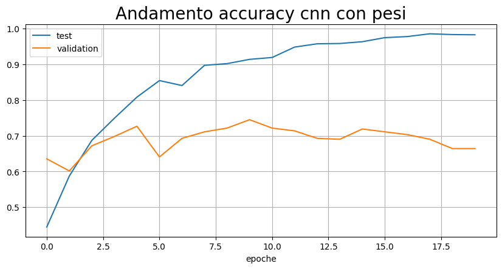

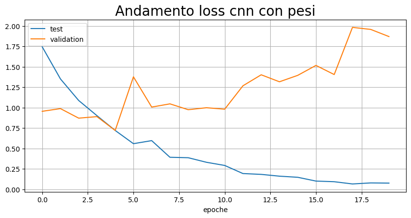

```python
plt.figure( figsize = (10,10) )

plt.subplot(2,1,1)
plot_graphs(weight_history, 'accuracy', title = 'Andamento accuracy cnn con pesi')
plt.show()

plt.figure( figsize = (10,10) )

plt.subplot(2,1,2)
plot_graphs(weight_history, 'loss', title = 'Andamento loss cnn con pesi')
plt.show()
```

```python
print('--- PERFORMANCE CNN con pesi ---\n')

loss_train, accuracy_train = weight_model.evaluate(train, verbose = 0)
print(f"Training Accuracy: {accuracy_train :.4f}")
print(f"Training Loss: {loss_train :.4f}")
print()
loss_test, accuracy_test = weight_model.evaluate(test, verbose = 0)
print(f"Testing Accuracy:  {accuracy_test:.4f}")
print(f"Testing Loss:  {loss_test:.4f}")
```

```
--- PERFORMANCE CNN con pesi ---

Training Accuracy: 0.9712
Training Loss: 0.0784

Testing Accuracy:  0.6429
Testing Loss:  2.2359
```

## **3° Modello: Regolarizzazione**

Poiché i due modelli precedenti hanno mostrato segni evidenti di overfitting, con alte performance in training ma cali significativi in testing, si è proceduto con l'applicare tecniche di **regolarizzazione** per migliorare la capacità di **generalizzazione**. Le strategie adottate sono schematizzate nella tabella seguente e includono:

### Impostazioni del modello

| Parametro | Valore |
| --- | --- |
| `p` | 3 |
| `filters` | `[32, 32, 64]` |
| `n` | 128 |
| `drop` | `[True, True, True]` |
| `reg` | `regularizers.l2(0.01)` |
| `optimizer` | `adam` |
| `loss` | `'categorical_crossentropy'` |
| `metrics` | `['accuracy']` |
| `epochs` | 30 |
| `EarlyStopping` | `patience = 5` |
| `ReduceLROnPlateau` | `factor = 0.5`, `patience = 2` |

### Risultati finali

| Metrica | Valore |
| --- | --- |
| Tempo di training | 2 min 16 sec |
| Accuracy (training) | 95% |
| **Accuracy (testing)** | **75%** |
| Loss (training) | 0.52 |
| **Loss (testing)** | **1.10** |
| **Best validation accuracy** | **77%** |

```python
reg_model = my_cnn(p = 3, filters = [32, 32, 64], n = 128, drop = [True, True, True], reg = regularizers.l2(0.01))
reg_model.summary()
```

```
Model: "sequential_7"
```

```
┏━━━━━━━━━━━━━━━━━━━━━━━━━━━━━━━━━┳━━━━━━━━━━━━━━━━━━━━━━━━┳━━━━━━━━━━━━━━━┓
┃ Layer (type)                    ┃ Output Shape           ┃       Param # ┃
┡━━━━━━━━━━━━━━━━━━━━━━━━━━━━━━━━━╇━━━━━━━━━━━━━━━━━━━━━━━━╇━━━━━━━━━━━━━━━┩
│ conv2d_19 (Conv2D)              │ (None, 224, 224, 32)   │           896 │
├─────────────────────────────────┼────────────────────────┼───────────────┤
│ max_pooling2d_19 (MaxPooling2D) │ (None, 112, 112, 32)   │             0 │
├─────────────────────────────────┼────────────────────────┼───────────────┤
│ conv2d_20 (Conv2D)              │ (None, 112, 112, 32)   │         9,248 │
├─────────────────────────────────┼────────────────────────┼───────────────┤
│ max_pooling2d_20 (MaxPooling2D) │ (None, 56, 56, 32)     │             0 │
├─────────────────────────────────┼────────────────────────┼───────────────┤
│ conv2d_21 (Conv2D)              │ (None, 56, 56, 64)     │        18,496 │
├─────────────────────────────────┼────────────────────────┼───────────────┤
│ max_pooling2d_21 (MaxPooling2D) │ (None, 28, 28, 64)     │             0 │
├─────────────────────────────────┼────────────────────────┼───────────────┤
│ flatten_6 (Flatten)             │ (None, 50176)          │             0 │
├─────────────────────────────────┼────────────────────────┼───────────────┤
│ dropout_9 (Dropout)             │ (None, 50176)          │             0 │
├─────────────────────────────────┼────────────────────────┼───────────────┤
│ dense_18 (Dense)                │ (None, 128)            │     6,422,656 │
├─────────────────────────────────┼────────────────────────┼───────────────┤
│ dropout_10 (Dropout)            │ (None, 128)            │             0 │
├─────────────────────────────────┼────────────────────────┼───────────────┤
│ dense_19 (Dense)                │ (None, 64)             │         8,256 │
├─────────────────────────────────┼────────────────────────┼───────────────┤
│ dropout_11 (Dropout)            │ (None, 64)             │             0 │
├─────────────────────────────────┼────────────────────────┼───────────────┤
│ dense_20 (Dense)                │ (None, 5)              │           325 │
└─────────────────────────────────┴────────────────────────┴───────────────┘
```

```
 Total params: 6,459,877 (24.64 MB)
```

```
 Trainable params: 6,459,877 (24.64 MB)
```

```
 Non-trainable params: 0 (0.00 B)
```

```python
reg_model.compile(optimizer = 'adam', loss = 'categorical_crossentropy', metrics = ['accuracy'])
early_stop = callbacks.EarlyStopping(monitor = 'val_loss', patience = 5, restore_best_weights = True)   # utilizzo dell'earlystopping per controllare aumenti di val_loss
lr_scheduler = callbacks.ReduceLROnPlateau(monitor = 'val_loss', factor = 0.5, patience = 2, min_lr = 1e-6)   # Utilizzo di reducelronplateau per controllare learning rate
```

```python
start = time.time()
reg_history = reg_model.fit(train, epochs = 30, verbose = 1, validation_data = val, class_weight = cw, callbacks = [early_stop, lr_scheduler])
end = time.time()
```

```
57/57 ━━━━━━━━━━━━━━━━━━━━ 11s 113ms/step - accuracy: 0.2758 - loss: 4.8601 - val_accuracy: 0.4661 - val_loss: 2.2138 - learning_rate: 0.0010
57/57 ━━━━━━━━━━━━━━━━━━━━ 5s 64ms/step - accuracy: 0.4691 - loss: 2.5448 - val_accuracy: 0.5312 - val_loss: 1.6840 - learning_rate: 0.0010
57/57 ━━━━━━━━━━━━━━━━━━━━ 5s 63ms/step - accuracy: 0.5423 - loss: 2.0945 - val_accuracy: 0.6042 - val_loss: 1.4772 - learning_rate: 0.0010
57/57 ━━━━━━━━━━━━━━━━━━━━ 4s 63ms/step - accuracy: 0.5911 - loss: 1.9348 - val_accuracy: 0.6094 - val_loss: 1.4969 - learning_rate: 0.0010
57/57 ━━━━━━━━━━━━━━━━━━━━ 5s 63ms/step - accuracy: 0.6067 - loss: 1.8607 - val_accuracy: 0.6641 - val_loss: 1.3134 - learning_rate: 0.0010
57/57 ━━━━━━━━━━━━━━━━━━━━ 4s 63ms/step - accuracy: 0.6533 - loss: 1.7061 - val_accuracy: 0.6484 - val_loss: 1.3022 - learning_rate: 0.0010
57/57 ━━━━━━━━━━━━━━━━━━━━ 4s 63ms/step - accuracy: 0.6586 - loss: 1.6642 - val_accuracy: 0.6927 - val_loss: 1.2158 - learning_rate: 0.0010
57/57 ━━━━━━━━━━━━━━━━━━━━ 4s 62ms/step - accuracy: 0.6974 - loss: 1.5279 - val_accuracy: 0.6432 - val_loss: 1.3118 - learning_rate: 0.0010
57/57 ━━━━━━━━━━━━━━━━━━━━ 4s 63ms/step - accuracy: 0.6868 - loss: 1.5742 - val_accuracy: 0.6849 - val_loss: 1.2305 - learning_rate: 0.0010
57/57 ━━━━━━━━━━━━━━━━━━━━ 5s 62ms/step - accuracy: 0.7244 - loss: 1.4286 - val_accuracy: 0.6823 - val_loss: 1.1413 - learning_rate: 5.0000e-04
57/57 ━━━━━━━━━━━━━━━━━━━━ 5s 63ms/step - accuracy: 0.7399 - loss: 1.3294 - val_accuracy: 0.7083 - val_loss: 1.1322 - learning_rate: 5.0000e-04
57/57 ━━━━━━━━━━━━━━━━━━━━ 4s 63ms/step - accuracy: 0.7633 - loss: 1.2718 - val_accuracy: 0.6875 - val_loss: 1.1458 - learning_rate: 5.0000e-04
57/57 ━━━━━━━━━━━━━━━━━━━━ 5s 62ms/step - accuracy: 0.7714 - loss: 1.2214 - val_accuracy: 0.6927 - val_loss: 1.1535 - learning_rate: 5.0000e-04
57/57 ━━━━━━━━━━━━━━━━━━━━ 5s 63ms/step - accuracy: 0.7893 - loss: 1.1852 - val_accuracy: 0.7135 - val_loss: 1.0715 - learning_rate: 2.5000e-04
57/57 ━━━━━━━━━━━━━━━━━━━━ 5s 62ms/step - accuracy: 0.8281 - loss: 1.0630 - val_accuracy: 0.7031 - val_loss: 1.1224 - learning_rate: 2.5000e-04
57/57 ━━━━━━━━━━━━━━━━━━━━ 4s 62ms/step - accuracy: 0.8257 - loss: 1.0443 - val_accuracy: 0.7552 - val_loss: 1.0198 - learning_rate: 2.5000e-04
57/57 ━━━━━━━━━━━━━━━━━━━━ 4s 62ms/step - accuracy: 0.8395 - loss: 0.9645 - val_accuracy: 0.7448 - val_loss: 1.0514 - learning_rate: 2.5000e-04
57/57 ━━━━━━━━━━━━━━━━━━━━ 5s 63ms/step - accuracy: 0.8564 - loss: 0.9298 - val_accuracy: 0.7344 - val_loss: 1.0604 - learning_rate: 2.5000e-04
57/57 ━━━━━━━━━━━━━━━━━━━━ 4s 62ms/step - accuracy: 0.8680 - loss: 0.8786 - val_accuracy: 0.7396 - val_loss: 1.0133 - learning_rate: 1.2500e-04
57/57 ━━━━━━━━━━━━━━━━━━━━ 5s 63ms/step - accuracy: 0.8852 - loss: 0.8283 - val_accuracy: 0.7552 - val_loss: 1.0041 - learning_rate: 1.2500e-04
57/57 ━━━━━━━━━━━━━━━━━━━━ 5s 62ms/step - accuracy: 0.8871 - loss: 0.7879 - val_accuracy: 0.7578 - val_loss: 1.0021 - learning_rate: 1.2500e-04
57/57 ━━━━━━━━━━━━━━━━━━━━ 4s 62ms/step - accuracy: 0.9089 - loss: 0.7324 - val_accuracy: 0.7396 - val_loss: 1.0365 - learning_rate: 1.2500e-04
57/57 ━━━━━━━━━━━━━━━━━━━━ 4s 62ms/step - accuracy: 0.9077 - loss: 0.7254 - val_accuracy: 0.7552 - val_loss: 1.0167 - learning_rate: 1.2500e-04
57/57 ━━━━━━━━━━━━━━━━━━━━ 5s 63ms/step - accuracy: 0.9155 - loss: 0.6929 - val_accuracy: 0.7578 - val_loss: 1.0206 - learning_rate: 6.2500e-05
57/57 ━━━━━━━━━━━━━━━━━━━━ 4s 62ms/step - accuracy: 0.9168 - loss: 0.7027 - val_accuracy: 0.7682 - val_loss: 0.9948 - learning_rate: 6.2500e-05
57/57 ━━━━━━━━━━━━━━━━━━━━ 4s 62ms/step - accuracy: 0.9261 - loss: 0.6674 - val_accuracy: 0.7578 - val_loss: 1.0124 - learning_rate: 6.2500e-05
57/57 ━━━━━━━━━━━━━━━━━━━━ 4s 62ms/step - accuracy: 0.9184 - loss: 0.6947 - val_accuracy: 0.7630 - val_loss: 1.0094 - learning_rate: 6.2500e-05
57/57 ━━━━━━━━━━━━━━━━━━━━ 4s 63ms/step - accuracy: 0.9297 - loss: 0.6288 - val_accuracy: 0.7734 - val_loss: 1.0075 - learning_rate: 3.1250e-05
57/57 ━━━━━━━━━━━━━━━━━━━━ 5s 62ms/step - accuracy: 0.9383 - loss: 0.6281 - val_accuracy: 0.7708 - val_loss: 1.0084 - learning_rate: 3.1250e-05
57/57 ━━━━━━━━━━━━━━━━━━━━ 5s 62ms/step - accuracy: 0.9390 - loss: 0.6167 - val_accuracy: 0.7734 - val_loss: 1.0098 - learning_rate: 1.5625e-05
```

```python
print("Tempo impiegato per l'addestramento -->", round(end-start,3),'sec')
```

```
Tempo impiegato per l'addestramento --> 135.899 sec
```

## Interpretazione dei Risultati

Il modello è più *stabile* dei precedenti. La loss sul set di validazione diminuisce costantemente nelle prime epoche, raggiungendo una fase di plateau a partire circa dalla **15-esima epoca**. Questo comportamento indica che il modello sta imparando in modo più controllato, evitando l’overfitting e migliorando la capacità di generalizzare su dati non visti.

> Il modello regolarizzato sembra offrire le migliori **prestazioni** finora, tuttavia ci sono ancora margini di miglioramento.

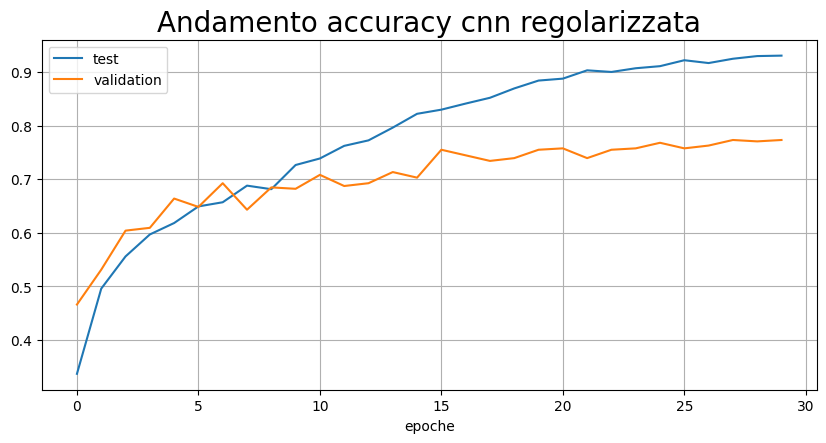

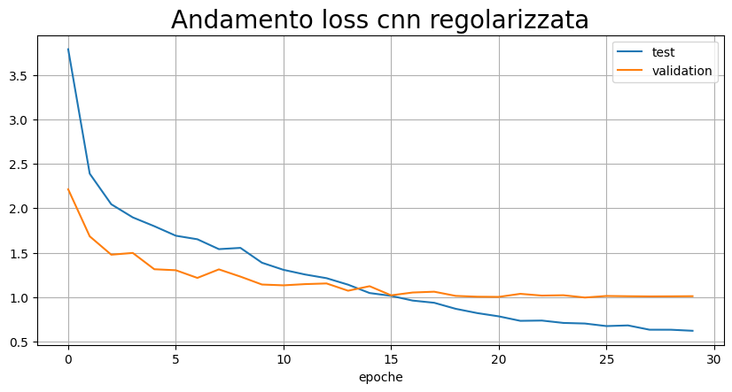

```python
plt.figure( figsize = (10,10) )

plt.subplot(2,1,1)
plot_graphs(reg_history, 'accuracy', title = 'Andamento accuracy cnn regolarizzata')
plt.show()

plt.figure( figsize = (10,10) )

plt.subplot(2,1,2)
plot_graphs(reg_history, 'loss', title = 'Andamento loss cnn regolarizzata')
plt.show()
```

```python
print('--- PERFORMANCE CNN con regolarizzazione ---\n')

loss_train, accuracy_train = reg_model.evaluate(train, verbose = 0)
print(f"Training Accuracy: {accuracy_train :.4f}")
print(f"Training Loss: {loss_train :.4f}")
print()
loss_test, accuracy_test = reg_model.evaluate(test, verbose = 0)
print(f"Testing Accuracy:  {accuracy_test:.4f}")
print(f"Testing Loss:  {loss_test:.4f}")
```

```
--- PERFORMANCE CNN con regolarizzazione ---

Training Accuracy: 0.9484
Training Loss: 0.5218

Testing Accuracy:  0.7513
Testing Loss:  1.0966
```

```python
y_hat_probs = reg_model.predict(test, verbose = 0)  # Predizioni sui dati di test: calcolo il vettore delle probabilità (di assegnazione ad una classe)
y_hat = np.argmax(y_hat_probs, axis=1)              # Seleziono l'indice della classe con probabilità maggiore, ossia l'etichetta predetta dal modello

for i in range(3):
  print(f'Vettore di probabilità della immagine {i+1} di test:')
  print(y_hat_probs[i])
  print(f"Classificazione etichetta corrispondente: {y_hat[i]} --> {class_names[y_hat[i]]}")
  print()
```

```
Vettore di probabilità della immagine 1 di test:
[0.15901124 0.00159387 0.00254043 0.10175062 0.73510385]
Classificazione etichetta corrispondente: 4 --> trash

Vettore di probabilità della immagine 2 di test:
[0.41365582 0.00183774 0.00093509 0.09637203 0.48719922]
Classificazione etichetta corrispondente: 4 --> trash

Vettore di probabilità della immagine 3 di test:
[2.2193260e-04 2.0454409e-05 9.9954385e-01 2.1144324e-04 2.2882336e-06]
Classificazione etichetta corrispondente: 2 --> paper
```

```python
y_true = []
for _, labels in test:
    y_true.extend(np.argmax(labels.numpy(), axis=1))    # Estrazione delle etichette reali dal set di test (convertendo le y da formato one-hot encoding a indici di classe)
y_true = np.array(y_true)
```

```python
M = confusion_matrix(y_true, y_hat)     # Matrice di confusione del modello regolarizzato
print('Confusion matrix:')
print(M)
```

```
Confusion matrix:
[[191   8  15  19  28]
 [ 20 159  11   2   0]
 [ 16   5 203  10   1]
 [ 20   7  23  94  18]
 [ 20   2   7  16 102]]
```

```python
# Funzione che visualizza la matrice di confunsione normalizzata
def plot_norm_confusion_matrix(M, class_names):

  M = M.astype('float')/M.sum(axis = 1)[:, np.newaxis]

  plt.figure( figsize = (8,8,) );
  sn.heatmap(M, annot = True, cmap = 'Blues', fmt = '.3f',
            xticklabels=class_names, yticklabels=class_names);
  plt.xlabel('Predetti');
  plt.ylabel('Reali');
  plt.xticks(rotation=45)
  plt.yticks(rotation=0)
  plt.title('Confusion Matrix normalizzata', fontsize = 20)
  plt.plot()
```

## Interpretazione della Matrice

La matrice di confusione è una metrica fondamentale per valutare le prestazioni di un modello di classificazione. In particolare, la **diagonale principale** rappresenta la percentuale di elementi di ciascuna classe $i$ classificati correttamente.

Nel nostro caso, si osservano *buone performance* per le classi **organico** (82.8%) e **carta** (86.4%), mentre la classe **plastica** presenta le *performance peggiori*, con un’accuratezza del 58%.

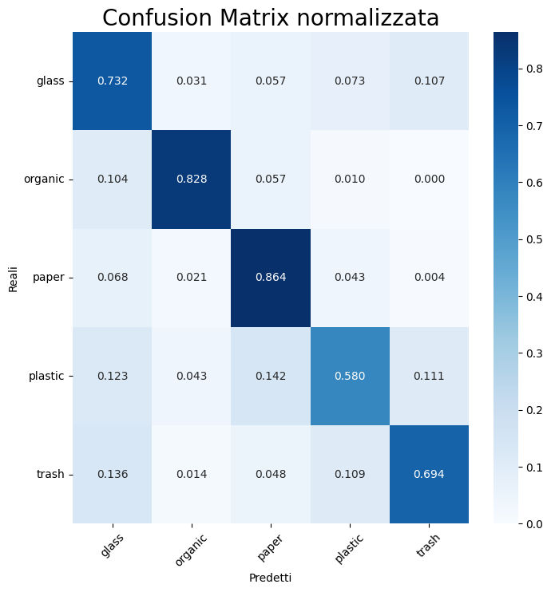

```python
plot_norm_confusion_matrix(M, class_names)
```

## **4° Modello: Data Augmentation**

Per ridurre ulteriormente il rischio di overfitting, sono state adottate tecniche di **data augmentation**. In particolare, nella fase iniziale del flusso di addestramento, le immagini subiscono *rotazioni*, *traslazioni* e altre *trasformazioni* tramite la funzione `data_augmentation()` precedentemente definita.

### Impostazioni del modello

[output not shown]

### Risultati finali

| Metrica | Valore |
| --- | --- |
| Tempo di training | 1 min 57 sec |
| Accuracy (training) | 77% |
| **Accuracy (testing)** | **75%** |
| Loss (training) | 0.57 |
| **Loss (testing)** | **0.66** |
| **Best validation accuracy** | **77%** |

```python
aug_model = my_cnn(p = 3, filters = [32, 32, 64], n = 256, aug = True)
```

```python
aug_model.summary()
```

```
Model: "sequential_13"
```

```
┏━━━━━━━━━━━━━━━━━━━━━━━━━━━━━━━━━┳━━━━━━━━━━━━━━━━━━━━━━━━┳━━━━━━━━━━━━━━━┓
┃ Layer (type)                    ┃ Output Shape           ┃       Param # ┃
┡━━━━━━━━━━━━━━━━━━━━━━━━━━━━━━━━━╇━━━━━━━━━━━━━━━━━━━━━━━━╇━━━━━━━━━━━━━━━┩
│ sequential_14 (Sequential)      │ (None, 224, 224, 3)    │             0 │
├─────────────────────────────────┼────────────────────────┼───────────────┤
│ conv2d_30 (Conv2D)              │ (None, 224, 224, 32)   │           896 │
├─────────────────────────────────┼────────────────────────┼───────────────┤
│ max_pooling2d_30 (MaxPooling2D) │ (None, 112, 112, 32)   │             0 │
├─────────────────────────────────┼────────────────────────┼───────────────┤
│ conv2d_31 (Conv2D)              │ (None, 112, 112, 32)   │         9,248 │
├─────────────────────────────────┼────────────────────────┼───────────────┤
│ max_pooling2d_31 (MaxPooling2D) │ (None, 56, 56, 32)     │             0 │
├─────────────────────────────────┼────────────────────────┼───────────────┤
│ conv2d_32 (Conv2D)              │ (None, 56, 56, 64)     │        18,496 │
├─────────────────────────────────┼────────────────────────┼───────────────┤
│ max_pooling2d_32 (MaxPooling2D) │ (None, 28, 28, 64)     │             0 │
├─────────────────────────────────┼────────────────────────┼───────────────┤
│ flatten_10 (Flatten)            │ (None, 50176)          │             0 │
├─────────────────────────────────┼────────────────────────┼───────────────┤
│ dense_30 (Dense)                │ (None, 256)            │    12,845,312 │
├─────────────────────────────────┼────────────────────────┼───────────────┤
│ dense_31 (Dense)                │ (None, 128)            │        32,896 │
├─────────────────────────────────┼────────────────────────┼───────────────┤
│ dense_32 (Dense)                │ (None, 5)              │           645 │
└─────────────────────────────────┴────────────────────────┴───────────────┘
```

```
 Total params: 12,907,493 (49.24 MB)
```

```
 Trainable params: 12,907,493 (49.24 MB)
```

```
 Non-trainable params: 0 (0.00 B)
```

```python
from tensorflow.keras.optimizers import Adam

aug_model.compile(optimizer = Adam(learning_rate = 5e-4), loss = 'categorical_crossentropy', metrics = ['accuracy'])
```

```python
start = time.time()
aug_history = aug_model.fit(train, epochs = 50, verbose = 1, validation_data = val, callbacks = [early_stop, lr_scheduler], class_weight = cw)
end = time.time()
```

```
57/57 ━━━━━━━━━━━━━━━━━━━━ 7s 81ms/step - accuracy: 0.3189 - loss: 2.3259 - val_accuracy: 0.5000 - val_loss: 1.1524 - learning_rate: 5.0000e-04
57/57 ━━━━━━━━━━━━━━━━━━━━ 4s 72ms/step - accuracy: 0.4939 - loss: 1.6188 - val_accuracy: 0.4323 - val_loss: 1.2739 - learning_rate: 5.0000e-04
57/57 ━━━━━━━━━━━━━━━━━━━━ 4s 73ms/step - accuracy: 0.5389 - loss: 1.5232 - val_accuracy: 0.6562 - val_loss: 0.8575 - learning_rate: 5.0000e-04
57/57 ━━━━━━━━━━━━━━━━━━━━ 5s 74ms/step - accuracy: 0.5869 - loss: 1.3804 - val_accuracy: 0.6016 - val_loss: 0.9812 - learning_rate: 5.0000e-04
57/57 ━━━━━━━━━━━━━━━━━━━━ 5s 74ms/step - accuracy: 0.6240 - loss: 1.2938 - val_accuracy: 0.5833 - val_loss: 0.9920 - learning_rate: 5.0000e-04
57/57 ━━━━━━━━━━━━━━━━━━━━ 4s 73ms/step - accuracy: 0.6536 - loss: 1.1980 - val_accuracy: 0.6328 - val_loss: 0.8662 - learning_rate: 2.5000e-04
57/57 ━━━━━━━━━━━━━━━━━━━━ 5s 75ms/step - accuracy: 0.6806 - loss: 1.1173 - val_accuracy: 0.6510 - val_loss: 0.8779 - learning_rate: 2.5000e-04
57/57 ━━━━━━━━━━━━━━━━━━━━ 4s 75ms/step - accuracy: 0.6977 - loss: 1.0872 - val_accuracy: 0.6849 - val_loss: 0.7589 - learning_rate: 1.2500e-04
57/57 ━━━━━━━━━━━━━━━━━━━━ 4s 76ms/step - accuracy: 0.7074 - loss: 1.0262 - val_accuracy: 0.6823 - val_loss: 0.7407 - learning_rate: 1.2500e-04
57/57 ━━━━━━━━━━━━━━━━━━━━ 4s 76ms/step - accuracy: 0.7115 - loss: 1.0099 - val_accuracy: 0.7005 - val_loss: 0.7474 - learning_rate: 1.2500e-04
57/57 ━━━━━━━━━━━━━━━━━━━━ 5s 77ms/step - accuracy: 0.7198 - loss: 0.9845 - val_accuracy: 0.7057 - val_loss: 0.7400 - learning_rate: 1.2500e-04
57/57 ━━━━━━━━━━━━━━━━━━━━ 4s 76ms/step - accuracy: 0.7173 - loss: 0.9686 - val_accuracy: 0.7188 - val_loss: 0.7151 - learning_rate: 1.2500e-04
57/57 ━━━━━━━━━━━━━━━━━━━━ 4s 76ms/step - accuracy: 0.7274 - loss: 0.9617 - val_accuracy: 0.7083 - val_loss: 0.7483 - learning_rate: 1.2500e-04
57/57 ━━━━━━━━━━━━━━━━━━━━ 4s 77ms/step - accuracy: 0.7403 - loss: 0.9446 - val_accuracy: 0.7214 - val_loss: 0.7127 - learning_rate: 1.2500e-04
57/57 ━━━━━━━━━━━━━━━━━━━━ 4s 76ms/step - accuracy: 0.7417 - loss: 0.9273 - val_accuracy: 0.7188 - val_loss: 0.7026 - learning_rate: 1.2500e-04
57/57 ━━━━━━━━━━━━━━━━━━━━ 4s 77ms/step - accuracy: 0.7472 - loss: 0.9092 - val_accuracy: 0.7344 - val_loss: 0.6776 - learning_rate: 1.2500e-04
57/57 ━━━━━━━━━━━━━━━━━━━━ 4s 75ms/step - accuracy: 0.7571 - loss: 0.9018 - val_accuracy: 0.7188 - val_loss: 0.6974 - learning_rate: 1.2500e-04
57/57 ━━━━━━━━━━━━━━━━━━━━ 5s 75ms/step - accuracy: 0.7415 - loss: 0.9021 - val_accuracy: 0.7318 - val_loss: 0.6845 - learning_rate: 1.2500e-04
57/57 ━━━━━━━━━━━━━━━━━━━━ 4s 76ms/step - accuracy: 0.7502 - loss: 0.8821 - val_accuracy: 0.7448 - val_loss: 0.6508 - learning_rate: 6.2500e-05
57/57 ━━━━━━━━━━━━━━━━━━━━ 4s 75ms/step - accuracy: 0.7602 - loss: 0.8455 - val_accuracy: 0.7656 - val_loss: 0.6155 - learning_rate: 6.2500e-05
57/57 ━━━━━━━━━━━━━━━━━━━━ 4s 74ms/step - accuracy: 0.7597 - loss: 0.8508 - val_accuracy: 0.7474 - val_loss: 0.6287 - learning_rate: 6.2500e-05
57/57 ━━━━━━━━━━━━━━━━━━━━ 5s 74ms/step - accuracy: 0.7720 - loss: 0.8312 - val_accuracy: 0.7526 - val_loss: 0.6343 - learning_rate: 6.2500e-05
57/57 ━━━━━━━━━━━━━━━━━━━━ 5s 74ms/step - accuracy: 0.7646 - loss: 0.8271 - val_accuracy: 0.7474 - val_loss: 0.6390 - learning_rate: 3.1250e-05
57/57 ━━━━━━━━━━━━━━━━━━━━ 5s 76ms/step - accuracy: 0.7797 - loss: 0.8136 - val_accuracy: 0.7474 - val_loss: 0.6417 - learning_rate: 3.1250e-05
57/57 ━━━━━━━━━━━━━━━━━━━━ 5s 74ms/step - accuracy: 0.7765 - loss: 0.8073 - val_accuracy: 0.7604 - val_loss: 0.6476 - learning_rate: 1.5625e-05
```

```python
print("Tempo impiegato per l'addestramento -->", round(end-start,3),'sec')
```

```
Tempo impiegato per l'addestramento --> 117.719 sec
```

## Interpretazione dei Risultati

Il fatto che training e validation mostrino andamenti simili e migliorativi è un segnale **positivo**: il modello sta imparando in modo stabile e bilanciato, senza *“memorizzare”* eccessivamente i dati di addestramento.

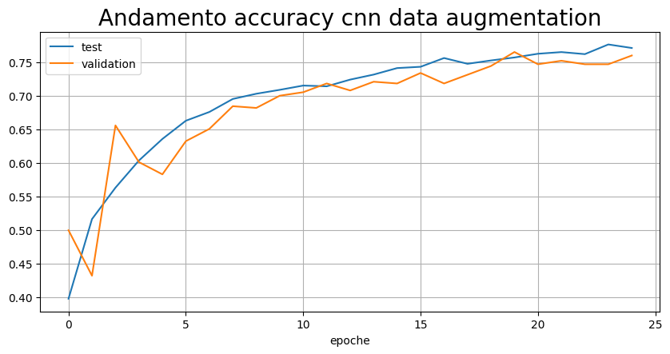

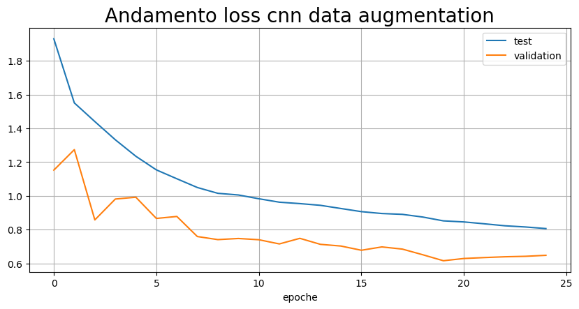

```python
plt.figure( figsize = (10,10) )

plt.subplot(2,1,1)
plot_graphs(aug_history, 'accuracy', title = 'Andamento accuracy cnn data augmentation')
plt.show()

plt.figure( figsize = (10,10) )

plt.subplot(2,1,2)
plot_graphs(aug_history, 'loss', title = 'Andamento loss cnn data augmentation')
plt.show()
```

```python
print('--- PERFORMANCE CNN con data augmentation ---\n')

loss_train, accuracy_train = aug_model.evaluate(train, verbose = 0)
print(f"Training Accuracy: {accuracy_train :.4f}")
print(f"Training Loss: {loss_train :.4f}")
print()
loss_test, accuracy_test = aug_model.evaluate(test, verbose = 0)
print(f"Testing Accuracy:  {accuracy_test:.4f}")
print(f"Testing Loss:  {loss_test:.4f}")
```

```
--- PERFORMANCE CNN con data augmentation ---

Training Accuracy: 0.7716
Training Loss: 0.5724

Testing Accuracy:  0.7482
Testing Loss:  0.6638
```

```python
y_hat_probs = aug_model.predict(test, verbose = 0)
y_hat = np.argmax(y_hat_probs, axis=1)
```

```python
M = confusion_matrix(y_true, y_hat)
print('Confusion matrix:')
print(M)
```

```
Confusion matrix:
[[179   9  21  22  30]
 [ 12 158  22   0   0]
 [ 12   6 209   8   0]
 [ 12   8  21 101  20]
 [ 16   1  10  21  99]]
```

## Interpretazione della Matrice

La matrice di confusione di tale modello evidenza *ottime performance* per le classi **organico** (82.3%) e **carta** (88.9%), mentre le restanti classi mostrano *risultati discreti*, con valori di accuratezza compresi tra il 62% e il 69%.

Nonostante i **buoni risultati** complessivi, il modello può senz’altro essere ulteriormente migliorato:

> per questo si è proceduto con tecniche di **transfer learning** al fine di ottimizzare le prestazioni soprattutto per le classi *meno performanti*.

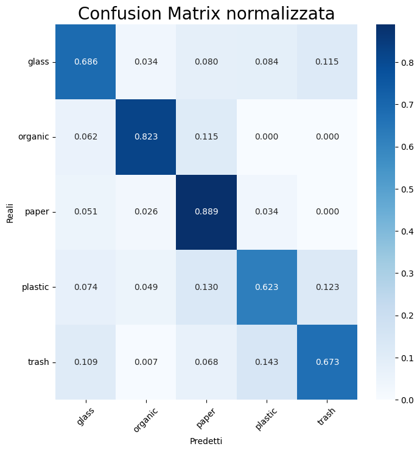

```python
plot_norm_confusion_matrix(M, class_names)
```

## **5° Modello: Trasfer learning con MobileNet**

La tecnica del **trasfer learning** consiste nel riutilizzare un modello *pre-addestrato* su un grande dataset, in questo caso **MobileNet**, come punto di partenza, invece di partire da pesi inizializzati casualmente. Questa strategia è utile perché:

- *Riduce i tempi di addestramento*: il modello parte già con conoscenze generali e non deve impararle da **zero**.
- *Richiede meno dati di training*: è particolarmente vantaggiosa quando il dataset a disposizione è **limitato**.
- *Migliora la generalizzazione*: sfruttando feature apprese da milioni di immagini, la rete può **adattarsi** meglio a nuovi dati.
- *Diminuisce il rischio di overfitting*: la base pre-addestrata è già **regolarizzata** da un dataset ampio e vario.
- *Flessibilità*: è possibile mantenere la base della rete e sostituire la parte finale con un **classificatore personalizzato** per il problema specifico.

### Impostazioni del modello

[output not shown]

### Risultati finali

| Metrica | Valore |
| --- | --- |
| Tempo di training | 58 sec |
| Accuracy (training) | 99% |
| **Accuracy (testing)** | **93%** |
| Loss (training) | 0.003 |
| **Loss (testing)** | **0.367** |
| **Best validation accuracy** | **92%** |

```python
# include_top = False --> non considera la parte della CNN che permette di classificare
resnet_model = applications.MobileNetV2(weights = "imagenet", include_top = False, input_shape = (224,224,3))
```

```
Downloading data from https://storage.googleapis.com/tensorflow/keras-applications/mobilenet_v2/mobilenet_v2_weights_tf_dim_ordering_tf_kernels_1.0_224_no_top.h5
9406464/9406464 ━━━━━━━━━━━━━━━━━━━━ 1s 0us/step
```

```python
resnet_transfer = models.Sequential(
    [
        resnet_model,

        # Definisco il classificatore personalizzato da aggiungere alla base CNN
        layers.Flatten(),
        layers.Dense(128, activation = "relu"),
        layers.Dense(5, activation = "softmax")

    ]

)
resnet_transfer.summary()
```

```
Model: "sequential_16"
```

```
┏━━━━━━━━━━━━━━━━━━━━━━━━━━━━━━━━━┳━━━━━━━━━━━━━━━━━━━━━━━━┳━━━━━━━━━━━━━━━┓
┃ Layer (type)                    ┃ Output Shape           ┃       Param # ┃
┡━━━━━━━━━━━━━━━━━━━━━━━━━━━━━━━━━╇━━━━━━━━━━━━━━━━━━━━━━━━╇━━━━━━━━━━━━━━━┩
│ mobilenetv2_1.00_224            │ (None, 7, 7, 1280)     │     2,257,984 │
│ (Functional)                    │                        │               │
├─────────────────────────────────┼────────────────────────┼───────────────┤
│ flatten_12 (Flatten)            │ (None, 62720)          │             0 │
├─────────────────────────────────┼────────────────────────┼───────────────┤
│ dense_35 (Dense)                │ (None, 128)            │     8,028,288 │
├─────────────────────────────────┼────────────────────────┼───────────────┤
│ dense_36 (Dense)                │ (None, 5)              │           645 │
└─────────────────────────────────┴────────────────────────┴───────────────┘
```

```
 Total params: 10,286,917 (39.24 MB)
```

```
 Trainable params: 10,252,805 (39.11 MB)
```

```
 Non-trainable params: 34,112 (133.25 KB)
```

```python
# Blocco i pesi della rete per evitare che vengano aggiornati durante la backpropagation, così da preservare le feature apprese nel pre-addestramento
for layer in resnet_model.layers:
  layer.trainable = False
```

```python
resnet_transfer.compile(optimizer="adam", loss="categorical_crossentropy", metrics=["accuracy"])
```

```python
start = time.time()
resnet_history = resnet_transfer.fit(train, epochs = 30, verbose = 1, validation_data = val, callbacks = [early_stop, lr_scheduler], class_weight = cw)
end = time.time()
```

```
57/57 ━━━━━━━━━━━━━━━━━━━━ 22s 185ms/step - accuracy: 0.7445 - loss: 3.8539 - val_accuracy: 0.8698 - val_loss: 0.5045 - learning_rate: 0.0010
57/57 ━━━━━━━━━━━━━━━━━━━━ 3s 56ms/step - accuracy: 0.9522 - loss: 0.2528 - val_accuracy: 0.8932 - val_loss: 0.4135 - learning_rate: 0.0010
57/57 ━━━━━━━━━━━━━━━━━━━━ 5s 54ms/step - accuracy: 0.9709 - loss: 0.1124 - val_accuracy: 0.9062 - val_loss: 0.4046 - learning_rate: 0.0010
57/57 ━━━━━━━━━━━━━━━━━━━━ 5s 53ms/step - accuracy: 0.9921 - loss: 0.0394 - val_accuracy: 0.9115 - val_loss: 0.4554 - learning_rate: 0.0010
57/57 ━━━━━━━━━━━━━━━━━━━━ 3s 56ms/step - accuracy: 0.9967 - loss: 0.0118 - val_accuracy: 0.9193 - val_loss: 0.3949 - learning_rate: 0.0010
57/57 ━━━━━━━━━━━━━━━━━━━━ 3s 53ms/step - accuracy: 0.9985 - loss: 0.0067 - val_accuracy: 0.9193 - val_loss: 0.4094 - learning_rate: 0.0010
57/57 ━━━━━━━━━━━━━━━━━━━━ 3s 52ms/step - accuracy: 0.9989 - loss: 0.0037 - val_accuracy: 0.9193 - val_loss: 0.4079 - learning_rate: 0.0010
57/57 ━━━━━━━━━━━━━━━━━━━━ 3s 52ms/step - accuracy: 0.9999 - loss: 0.0012 - val_accuracy: 0.9167 - val_loss: 0.4097 - learning_rate: 5.0000e-04
57/57 ━━━━━━━━━━━━━━━━━━━━ 5s 54ms/step - accuracy: 0.9999 - loss: 0.0010 - val_accuracy: 0.9167 - val_loss: 0.4119 - learning_rate: 5.0000e-04
57/57 ━━━━━━━━━━━━━━━━━━━━ 5s 53ms/step - accuracy: 0.9999 - loss: 9.3877e-04 - val_accuracy: 0.9167 - val_loss: 0.4128 - learning_rate: 2.5000e-04
```

```python
print("Tempo impiegato per l'addestramento -->", round(end-start,3),'sec')
```

```
Tempo impiegato per l'addestramento --> 57.629 sec
```

## Interpretazione dei Risultati

L'**accuracy** di test e validation restano stabili dopo la 5° epoca rispettivamente al 99% e 92%. Un discorso analogo può essere fatto per la **loss**.

Grazie all’**EarlyStopping**, sono state necessarie solo 10 epoche per completare l’addestramento, con una conseguente riduzione del tempo computazionale.

Il modello risulta molto più **performante** rispetti ai precedente, con una netta differenza di accuratezza e stabilità.

> L’elevata qualità delle predizioni è confermata anche dalla matrice di confusione riportata di seguito.

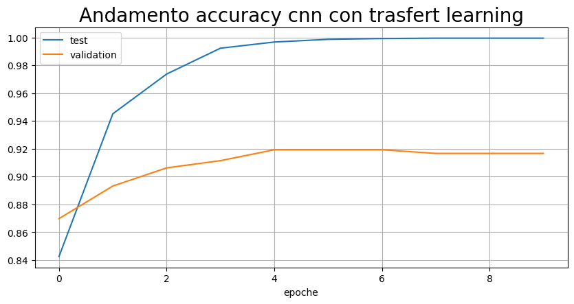

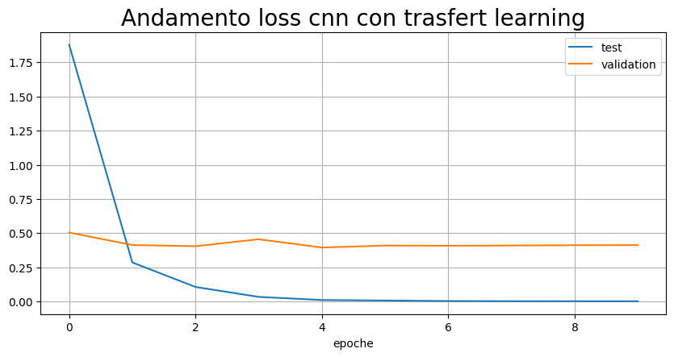

```python
plt.figure( figsize = (10,10) )

plt.subplot(2,1,1)
plot_graphs(resnet_history, 'accuracy', title = 'Andamento accuracy cnn con trasfert learning')
plt.show()

plt.figure( figsize = (10,10) )

plt.subplot(2,1,2)
plot_graphs(resnet_history, 'loss', title = 'Andamento loss cnn con trasfert learning')
plt.show()
```

```python
print('--- PERFORMANCE CNN con MobileNetV2 ---\n')

loss_train, accuracy_train = resnet_transfer.evaluate(train, verbose = 0)
print(f"Training Accuracy: {accuracy_train :.4f}")
print(f"Training Loss: {loss_train :.4f}")
print()
loss_test, accuracy_test = resnet_transfer.evaluate(test, verbose = 0)
print(f"Testing Accuracy:  {accuracy_test:.4f}")
print(f"Testing Loss:  {loss_test:.4f}")
```

```
--- PERFORMANCE CNN con MobileNetV2 ---

Training Accuracy: 0.9992
Training Loss: 0.0033

Testing Accuracy:  0.9348
Testing Loss:  0.3668
```

```python
y_hat_probs = resnet_transfer.predict(test, verbose = 0)
y_hat = np.argmax(y_hat_probs, axis=1)
```

```python
M = confusion_matrix(y_true, y_hat)
print('Confusion matrix:')
print(M)
```

```
Confusion matrix:
[[248   2   0   6   5]
 [  2 186   4   0   0]
 [  4   3 220   7   1]
 [ 22   0   4 135   1]
 [  2   0   2   0 143]]
```

## Interpretazione della Matrice

La matrice di confusione evidenzia che il modello riesce a classficare correttamente **oltre il 90%** delle immagini per le classi *vetro*, *organico*, *carta* e *indifferenziata*.

La classe *plastica* presenta un’accuratezza leggermente inferiore (83%), ma comunque ben superiore alle performance ottenute nei modelli precedenti.

> In sintesi, il modello dimostra ottime capacità di generalizzazione e una notevole affidabilità nella classificazione, confermando l’efficacia dell’approccio di **transfer learning** adottato.

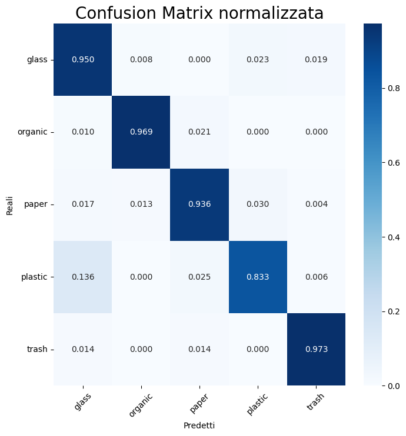

```python
plot_norm_confusion_matrix(M, class_names)
```

# **⚖️ Confronto finale**

Il grafico sottostante evidenzia chiaramente la **superiorità** del modello con *transfer learning* rispetto ai modelli precedenti, sia quello con *regolarizzazione* che quello con *data augmentation*.

> Inoltre, grazie all’uso di pesi pre-addestrati, il **numero di epoche** necessarie è risultato inferiore, con un notevole *risparmio di tempo e risorse computazionali*.

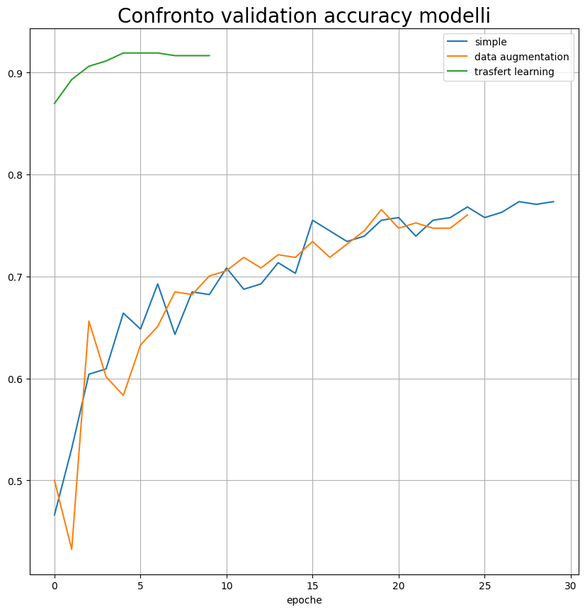

```python
plt.figure( figsize = (10,10) )

plt.plot(reg_history.history['val_accuracy'], label = 'simple')
plt.plot(aug_history.history['val_accuracy'], label = 'data augmentation')
plt.plot(resnet_history.history['val_accuracy'], label = 'trasfert learning')
plt.legend()
plt.title('Confronto validation accuracy modelli', fontsize = 20)
plt.xlabel('epoche')
plt.grid(True)
plt.show()
```

```python
print("Massima accuratezza sul validation test\n")
print("Simple -->", max(reg_history.history['val_accuracy']))
print("Data augmentation -->",  max(aug_history.history['val_accuracy']))
print("Trasfert learning -->",  max(resnet_history.history['val_accuracy']))
```

```
Massima accuratezza sul validation test

Simple --> 0.7734375
Data augmentation --> 0.765625
Trasfert learning --> 0.9192708134651184
```

```python
resnet_transfer.save("/content/drive/MyDrive/Smart_Waste_Project/best_model.h5")   #Salvo il modello in formato h5 per poter essere caricato nel progetto Flask
```